# ST 563 Project

### 200603898

# Project Overview

The SMS Spam Classifier is a machine learning model designed to distinguish between spam and legitimate (ham) messages. By analyzing text features and patterns, the model helps identify unwanted or fraudulent messages, improving user experience and security.

# Project Goal

The primary goal of this project is to develop a machine learning model that accurately classifies SMS messages as either **spam** or **ham (legitimate)**. Spam messages often contain fraudulent content, phishing attempts, or unwanted advertisements, making them a nuisance and a potential security risk for users.

By building this classifier, we aim to:

- **Enhance message filtering**: Reduce the likelihood of users receiving spam messages.
- **Improve security**: Identify and prevent phishing or scam messages.
- **Automate detection**: Provide an efficient, scalable solution for spam filtering.

The variable we are modeling is the **spam label (binary: spam or ham)** based on message content. Understanding the patterns in spam messages allows for better classification, ultimately improving communication safety and user experience.

# Data Description

The source of the data is Kaggle.

```python
import numpy as np
import pandas as pd
```

```python
df = pd.read_csv('/content/spam.csv', encoding='latin-1')
df.head()
```

|  | v1 | v2 | Unnamed: 2 | Unnamed: 3 | Unnamed: 4 |
| --- | --- | --- | --- | --- | --- |
| 0 | ham | Go until jurong point, crazy.. Available only ... | NaN | NaN | NaN |
| 1 | ham | Ok lar... Joking wif u oni... | NaN | NaN | NaN |
| 2 | spam | Free entry in 2 a wkly comp to win FA Cup fina... | NaN | NaN | NaN |
| 3 | ham | U dun say so early hor... U c already then say... | NaN | NaN | NaN |
| 4 | ham | Nah I don't think he goes to usf, he lives aro... | NaN | NaN | NaN |

```python
df.shape
```

```
(5572, 5)
```

# Data Cleaning

```python
df.info()
```

```
<class 'pandas.core.frame.DataFrame'>
RangeIndex: 5572 entries, 0 to 5571
Data columns (total 5 columns):
 #   Column      Non-Null Count  Dtype
---  ------      --------------  -----
 0   v1          5572 non-null   object
 1   v2          5572 non-null   object
 2   Unnamed: 2  50 non-null     object
 3   Unnamed: 3  12 non-null     object
 4   Unnamed: 4  6 non-null      object
dtypes: object(5)
memory usage: 217.8+ KB
```

```python
# drop last 3 columns
df.drop(columns=['Unnamed: 2', 'Unnamed: 3', 'Unnamed: 4'], inplace = True)
```

```python
df.sample(5)
```

|  | v1 | v2 |
| --- | --- | --- |
| 5059 | ham | I think i am disturbing her da |
| 92 | ham | Smile in Pleasure Smile in Pain Smile when tro... |
| 3465 | ham | Actually fuck that, just do whatever, do find ... |
| 2137 | ham | Then why you came to hostel. |
| 4712 | ham | Big brotherÛ÷s really scraped the barrel with... |

```python
# renaming the columns
df.rename(columns = {'v1' : 'target', 'v2' : 'text'}, inplace = True)
df.sample(5)
```

|  | target | text |
| --- | --- | --- |
| 2477 | ham | I'm done. I'm sorry. I hope your next space gi... |
| 3245 | ham | Funny fact Nobody teaches volcanoes 2 erupt, t... |
| 3839 | ham | HEY MATE! HOWS U HONEY?DID U AVE GOOD HOLIDAY?... |
| 461 | ham | Great. Never been better. Each day gives even ... |
| 2496 | ham | HCL chennai requires FRESHERS for voice proces... |

```python
from sklearn.preprocessing import LabelEncoder
encoder = LabelEncoder()
```

```python
df['target'] = encoder.fit_transform(df['target'])
```

```python
df.head()
```

|  | target | text |
| --- | --- | --- |
| 0 | 0 | Go until jurong point, crazy.. Available only ... |
| 1 | 0 | Ok lar... Joking wif u oni... |
| 2 | 1 | Free entry in 2 a wkly comp to win FA Cup fina... |
| 3 | 0 | U dun say so early hor... U c already then say... |
| 4 | 0 | Nah I don't think he goes to usf, he lives aro... |

```python
# missing values
df.isnull().sum()
```

|  | 0 |
| --- | --- |
| target | 0 |
| text | 0 |

**dtype:** int64

```python
# check for duplicate values
df.duplicated().sum()
```

```
np.int64(403)
```

```python
# remove duplicates
df = df.drop_duplicates(keep = 'first')
```

```python
df.shape
```

```
(5169, 2)
```

# Exploratory Data Analysis (EDA)

```python
df.head()
```

|  | target | text |
| --- | --- | --- |
| 0 | 0 | Go until jurong point, crazy.. Available only ... |
| 1 | 0 | Ok lar... Joking wif u oni... |
| 2 | 1 | Free entry in 2 a wkly comp to win FA Cup fina... |
| 3 | 0 | U dun say so early hor... U c already then say... |
| 4 | 0 | Nah I don't think he goes to usf, he lives aro... |

```python
df['target'].value_counts()
```

| target | count |
| --- | --- |
| 0 | 4516 |
| 1 | 653 |

**dtype:** int64

```python
import matplotlib.pyplot as plt
```

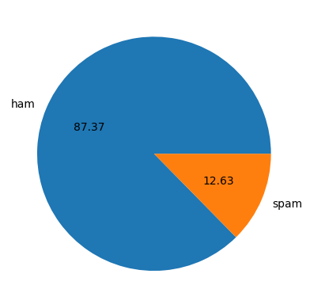

```python
plt.pie(df['target'].value_counts(), labels = ['ham', 'spam'], autopct = '%0.2f')
plt.show()
```

```python
import nltk
nltk.download('punkt')
nltk.download('punkt_tab') # Download the punkt_tab data

df['num_words'] = df['text'].apply(lambda x: len(nltk.word_tokenize(x)))
```

```python
!pip install nltk
```

```python
nltk.download('punkt')
```

```
True
```

```python
df['num_characters'] = df['text'].apply(len)
```

```python
df.head()
```

|  | target | text | num_words | num_characters |
| --- | --- | --- | --- | --- |
| 0 | 0 | Go until jurong point, crazy.. Available only ... | 24 | 111 |
| 1 | 0 | Ok lar... Joking wif u oni... | 8 | 29 |
| 2 | 1 | Free entry in 2 a wkly comp to win FA Cup fina... | 37 | 155 |
| 3 | 0 | U dun say so early hor... U c already then say... | 13 | 49 |
| 4 | 0 | Nah I don't think he goes to usf, he lives aro... | 15 | 61 |

```python
# num of words
df['num_words'] = df['text'].apply(lambda x: len(nltk.word_tokenize(x)))
```

```python
df.head()
```

|  | target | text | num_words | num_characters |
| --- | --- | --- | --- | --- |
| 0 | 0 | Go until jurong point, crazy.. Available only ... | 24 | 111 |
| 1 | 0 | Ok lar... Joking wif u oni... | 8 | 29 |
| 2 | 1 | Free entry in 2 a wkly comp to win FA Cup fina... | 37 | 155 |
| 3 | 0 | U dun say so early hor... U c already then say... | 13 | 49 |
| 4 | 0 | Nah I don't think he goes to usf, he lives aro... | 15 | 61 |

```python
# num of sentences
df['num_sentences'] = df['text'].apply(lambda x: len(nltk.sent_tokenize(x)))
```

```python
df.head()
```

|  | target | text | num_words | num_characters | num_sentences |
| --- | --- | --- | --- | --- | --- |
| 0 | 0 | Go until jurong point, crazy.. Available only ... | 24 | 111 | 2 |
| 1 | 0 | Ok lar... Joking wif u oni... | 8 | 29 | 2 |
| 2 | 1 | Free entry in 2 a wkly comp to win FA Cup fina... | 37 | 155 | 2 |
| 3 | 0 | U dun say so early hor... U c already then say... | 13 | 49 | 1 |
| 4 | 0 | Nah I don't think he goes to usf, he lives aro... | 15 | 61 | 1 |

```python
df[['num_characters', 'num_words', 'num_sentences']].describe()
```

|  | num_characters | num_words | num_sentences |
| --- | --- | --- | --- |
| count | 5169.000000 | 5169.000000 | 5169.000000 |
| mean | 78.977945 | 18.455794 | 1.965564 |
| std | 58.236293 | 13.324758 | 1.448541 |
| min | 2.000000 | 1.000000 | 1.000000 |
| 25% | 36.000000 | 9.000000 | 1.000000 |
| 50% | 60.000000 | 15.000000 | 1.000000 |
| 75% | 117.000000 | 26.000000 | 2.000000 |
| max | 910.000000 | 220.000000 | 38.000000 |

```python
# ham
df[df['target'] == 0][['num_characters', 'num_words', 'num_sentences']].describe()
```

|  | num_characters | num_words | num_sentences |
| --- | --- | --- | --- |
| count | 4516.000000 | 4516.000000 | 4516.000000 |
| mean | 70.459256 | 17.123782 | 1.820195 |
| std | 56.358207 | 13.493970 | 1.383657 |
| min | 2.000000 | 1.000000 | 1.000000 |
| 25% | 34.000000 | 8.000000 | 1.000000 |
| 50% | 52.000000 | 13.000000 | 1.000000 |
| 75% | 90.000000 | 22.000000 | 2.000000 |
| max | 910.000000 | 220.000000 | 38.000000 |

```python
# spam
df[df['target'] == 1][['num_characters', 'num_words', 'num_sentences']].describe()
```

|  | num_characters | num_words | num_sentences |
| --- | --- | --- | --- |
| count | 653.000000 | 653.000000 | 653.000000 |
| mean | 137.891271 | 27.667688 | 2.970904 |
| std | 30.137753 | 7.008418 | 1.488425 |
| min | 13.000000 | 2.000000 | 1.000000 |
| 25% | 132.000000 | 25.000000 | 2.000000 |
| 50% | 149.000000 | 29.000000 | 3.000000 |
| 75% | 157.000000 | 32.000000 | 4.000000 |
| max | 224.000000 | 46.000000 | 9.000000 |

```python
import seaborn as sns
```

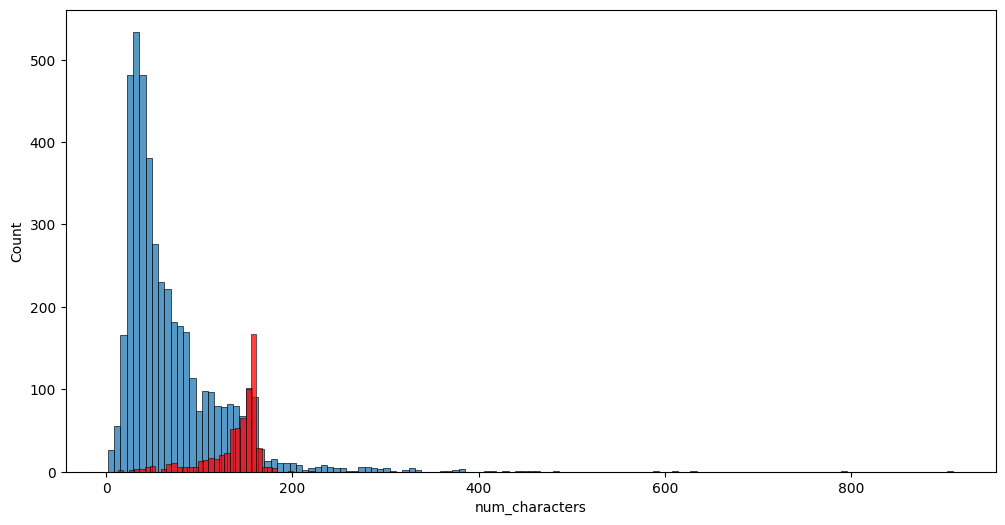

```python
plt.figure(figsize = (12,6))
sns.histplot(df[df['target'] == 0]['num_characters'])
sns.histplot(df[df['target'] == 1]['num_characters'], color = 'red')
```

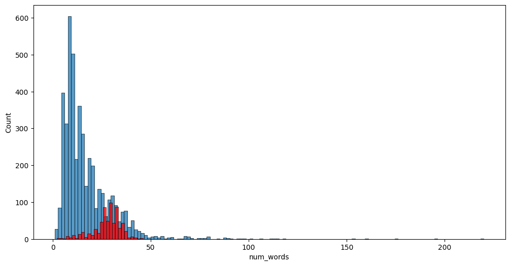

```python
plt.figure(figsize = (12,6))
sns.histplot(df[df['target'] == 0]['num_words'])
sns.histplot(df[df['target'] == 1]['num_words'], color = 'red')
```

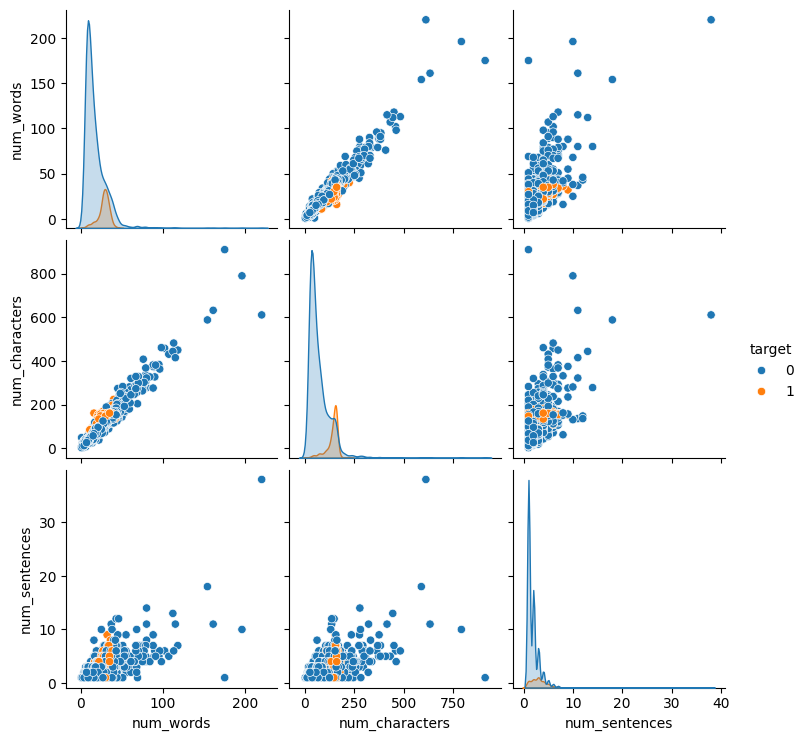

```python
sns.pairplot(df, hue = 'target')
```

```python
df_s = df.drop(columns = ['text'])
```

```python
df_s.corr()
```

|  | target | num_words | num_characters | num_sentences |
| --- | --- | --- | --- | --- |
| target | 1.000000 | 0.262912 | 0.384717 | 0.263939 |
| num_words | 0.262912 | 1.000000 | 0.965760 | 0.679971 |
| num_characters | 0.384717 | 0.965760 | 1.000000 | 0.624139 |
| num_sentences | 0.263939 | 0.679971 | 0.624139 | 1.000000 |

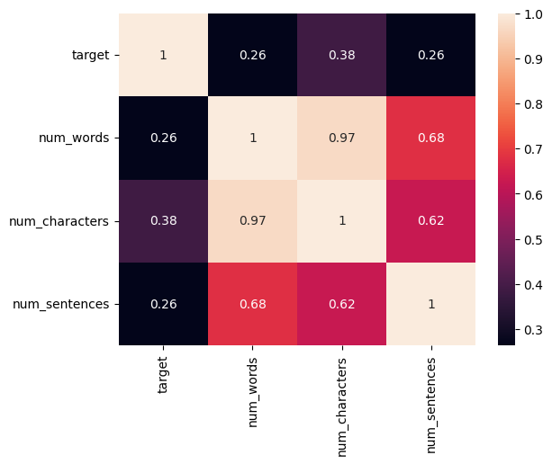

```python
sns.heatmap(df_s.corr(), annot = True)
```

# Data Preprocessing / Text Preprocessing

1. Lower Case
2. Tokenization
3. Removing Special Characters
4. Remove Stop Words and Punctuations
5. Stemming (dance/dancing/danced - take only dance since meaning is same)

```python
def transform_text(text):
  text = text.lower() # lowercase
  text = nltk.word_tokenize(text) # tokenization

  y = [] # remove special characters
  for i in text:
    if i.isalnum():
      y.append(i)

  text = y[:] # remove stop words and punctuations
  y.clear()
  for i in text:
    if i not in stopwords.words('english') and i not in string.punctuation:
      y.append(i)

  text = y[:] # stemming
  y.clear()
  for i in text:
    y.append(ps.stem(i))

  return " ".join(y)
```

```python
from nltk.corpus import stopwords
nltk.download('stopwords')
stopwords.words('english')
```

[output not shown]

[output cut: 143 more lines]

[output not shown]

```python
import string
string.punctuation
```

```
'!"#$%&\'()*+,-./:;<=>?@[\\]^_`{|}~'
```

```python
from nltk.stem.porter import PorterStemmer
ps = PorterStemmer()
ps.stem('loving')
```

```
'love'
```

```python
df['transformed_text'] = df['text'].apply(transform_text)
```

```python
df.head()
```

|  | target | text | num_words | num_characters | num_sentences | transformed_text |
| --- | --- | --- | --- | --- | --- | --- |
| 0 | 0 | Go until jurong point, crazy.. Available only ... | 24 | 111 | 2 | go jurong point crazi avail bugi n great world... |
| 1 | 0 | Ok lar... Joking wif u oni... | 8 | 29 | 2 | ok lar joke wif u oni |
| 2 | 1 | Free entry in 2 a wkly comp to win FA Cup fina... | 37 | 155 | 2 | free entri 2 wkli comp win fa cup final tkt 21... |
| 3 | 0 | U dun say so early hor... U c already then say... | 13 | 49 | 1 | u dun say earli hor u c alreadi say |
| 4 | 0 | Nah I don't think he goes to usf, he lives aro... | 15 | 61 | 1 | nah think goe usf live around though |

```python
# word cloud
from wordcloud import WordCloud
```

```python
wc = WordCloud(height = 500, width = 500, min_font_size = 10, background_color = 'white')
```

```python
spam_wc = wc.generate(df[df['target'] == 1]['transformed_text'].str.cat(sep = " "))
```

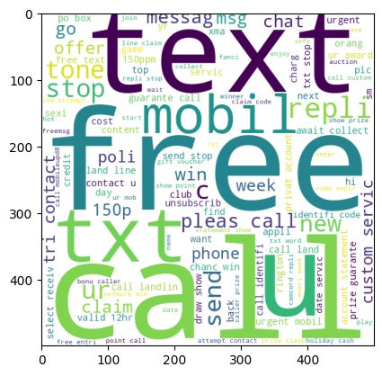

```python
plt.imshow(spam_wc)
```

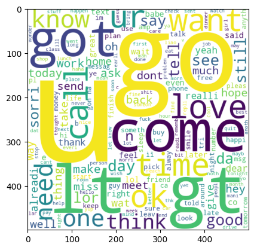

```python
ham_wc = wc.generate(df[df['target'] == 0]['transformed_text'].str.cat(sep = " "))
plt.imshow(ham_wc)
```

```python
spam_corpus = []
for msg in df[df['target'] == 1]['transformed_text'].tolist():
  for words in msg.split():
    spam_corpus.append(words)
```

```python
ham_corpus = []
for msg in df[df['target'] == 0]['transformed_text'].tolist():
  for words in msg.split():
    ham_corpus.append(words)
```

[figure not shown]

```python
from collections import Counter
sns.barplot(x = pd.DataFrame(Counter(spam_corpus).most_common(30))[0], y = pd.DataFrame(Counter(spam_corpus).most_common(30))[1])
plt.xticks(rotation = 'vertical')
plt.show()
```

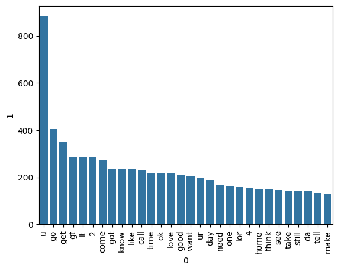

```python
sns.barplot(x = pd.DataFrame(Counter(ham_corpus).most_common(30))[0], y = pd.DataFrame(Counter(ham_corpus).most_common(30))[1])
plt.xticks(rotation = 'vertical')
plt.show()
```

# Model Building

```python
# bag of words
# tfidf vectorizer
# word 2 vector

from sklearn.feature_extraction.text import CountVectorizer, TfidfVectorizer
cv = CountVectorizer()
tfidf = TfidfVectorizer()
```

```python
X = tfidf.fit_transform(df['transformed_text']).toarray()
```

```python
X.shape
```

```
(5169, 6708)
```

```python
y = df['target'].values
```

```python
from sklearn.model_selection import train_test_split
from sklearn.metrics import accuracy_score, confusion_matrix, precision_score, f1_score, recall_score
```

```python
X_train, X_test, y_train, y_test = train_test_split(X, y, test_size = 0.2, random_state = 2)
```

```python
import pandas as pd
import numpy as np
from sklearn.model_selection import train_test_split, GridSearchCV
from sklearn.feature_extraction.text import TfidfVectorizer
from sklearn.preprocessing import StandardScaler
from sklearn.pipeline import Pipeline
from sklearn.metrics import classification_report, f1_score
from sklearn.linear_model import LogisticRegression
from sklearn.neighbors import KNeighborsClassifier
from sklearn.tree import DecisionTreeClassifier
from sklearn.ensemble import RandomForestClassifier, GradientBoostingClassifier
from sklearn.svm import SVC
import xgboost as xgb
```

```python
# Define models
models = {
    "Logistic Regression": LogisticRegression(),
    "kNN": KNeighborsClassifier(),
    "Decision Tree": DecisionTreeClassifier(),
    "Random Forest": RandomForestClassifier(),
    "Gradient Boosting": GradientBoostingClassifier(),
    "SVC": SVC()
}

# Hyperparameter tuning
param_grid = {
    "Logistic Regression": {"C": [0.1, 1, 10]},
    "kNN": {"n_neighbors": [3, 5, 7]},
    "Decision Tree": {"max_depth": [5, 10, 20]},
    "Random Forest": {"n_estimators": [50, 100], "max_depth": [5, 10]},
    "Gradient Boosting": {"n_estimators": [50, 100], "learning_rate": [0.1, 0.01]},
    "SVC": {"C": [0.1, 1, 10], "kernel": ["linear", "rbf"]}
}
```

# Model Descriptions

### (i) Logistic Regression

Type: Parametric model

Tuning parameters: Regularization strength (L1/L2 penalty via C in sklearn)

Inference possible? Yes, interpretable coefficients

Performs variable selection? Yes, if L1 (Lasso) regularization is used

Standardization needed? Yes (for numerical stability)

### (ii) k-Nearest Neighbors (kNN)

Type: Non-parametric model

Tuning parameters: Number of neighbors (k), distance metric (Euclidean, Manhattan)

Inference possible? No, it makes predictions based on neighbors, not learned parameters

Performs variable selection? No

Standardization needed? Yes (kNN is sensitive to feature scaling)

### (iii) Decision Tree

Type: Non-parametric model

Tuning parameters: Maximum depth, minimum samples per leaf

Inference possible? Yes (interpretable, but prone to overfitting)

Performs variable selection? Yes (implicitly selects important features)

Standardization needed? No (trees are not affected by feature scaling)

### (iv) Random Forest

Type: Ensemble of decision trees (non-parametric)

Tuning parameters: Number of trees (n_estimators), depth, minimum samples per split

Inference possible? Limited interpretability, feature importance ranking available

Performs variable selection? Yes

Standardization needed? No

Type: Ensemble learning (boosting)

Tuning parameters: Learning rate, number of estimators, max depth, min samples per leaf

Inference possible? Limited

Performs variable selection? Yes

Standardization needed? No

### (vi) Support Vector Classifier (SVC)

Type: Parametric if linear kernel, non-parametric if RBF

Tuning parameters: Kernel type, C (regularization), gamma (for RBF kernel)

Inference possible? Limited

Performs variable selection? No

Standardization needed? Yes (SVMs are sensitive to feature scaling)

```python
best_models = {}

for model_name, model in models.items():
    grid_search = GridSearchCV(model, param_grid[model_name], scoring='f1', cv=5)
    grid_search.fit(X_train, y_train)
    best_models[model_name] = grid_search.best_estimator_
    print(f"Best parameters for {model_name}: {grid_search.best_params_}")

# Evaluate models
'''for model_name, model in best_models.items():
    y_pred = model.predict(X_test_tfidf)
    print(f"\n=== {model_name} ===")
    print(classification_report(y_test, y_pred))'''
```

```
Best parameters for Logistic Regression: {'C': 10}
Best parameters for kNN: {'n_neighbors': 3}
Best parameters for Decision Tree: {'max_depth': 20}
Best parameters for Random Forest: {'max_depth': 10, 'n_estimators': 100}
Best parameters for Gradient Boosting: {'learning_rate': 0.1, 'n_estimators': 100}
Best parameters for SVC: {'C': 10, 'kernel': 'linear'}
```

```
'for model_name, model in best_models.items():\n    y_pred = model.predict(X_test_tfidf)\n    print(f"\n=== {model_name} ===")\n    print(classification_report(y_test, y_pred))'
```

```python
best_params = {
    "Logistic Regression": {"C": 10},
    "kNN": {"n_neighbors": 3},
    "Decision Tree": {"max_depth": 20},
    "Random Forest": {"n_estimators": 100, "max_depth": 10},
    "Gradient Boosting": {"n_estimators": 100, "learning_rate": 0.1},
    "SVC": {"C": 10, "kernel": "linear"}
}

models = {
    "Logistic Regression": LogisticRegression(**best_params["Logistic Regression"]),
    "kNN": KNeighborsClassifier(**best_params["kNN"]),
    "Decision Tree": DecisionTreeClassifier(**best_params["Decision Tree"]),
    "Random Forest": RandomForestClassifier(**best_params["Random Forest"]),
    "Gradient Boosting": GradientBoostingClassifier(**best_params["Gradient Boosting"]),
    "SVC": SVC(**best_params["SVC"])
}
```

```python
# Fit each model to the training set
for model_name, model in models.items():
    print(f"Fitting {model_name}...")
    model.fit(X_train, y_train)

print("All models have been trained on the training data.")
```

```
Fitting Logistic Regression...
Fitting kNN...
Fitting Decision Tree...
Fitting Random Forest...
Fitting Gradient Boosting...
Fitting SVC...
All models have been trained on the training data.
```

```python
# Dictionary to store results
results = {}

# Evaluate each model
for model_name, model in models.items():
    print(f"\n=== Evaluating {model_name} ===")

    # Predictions
    y_pred = model.predict(X_test)

    # Calculate metrics
    accuracy = accuracy_score(y_test, y_pred)
    precision = precision_score(y_test, y_pred)
    recall = recall_score(y_test, y_pred)
    f1 = f1_score(y_test, y_pred)

    # Store results
    results[model_name] = {
        "Accuracy": accuracy,
        "Precision": precision,
        "Recall": recall,
        "F1-Score": f1
    }

    # Print detailed report
    print(classification_report(y_test, y_pred))

# Identify the best model based on F1-score (or another metric if necessary)
best_model_name = max(results, key=lambda x: results[x]["F1-Score"])
best_model = models[best_model_name]

print(f"\n🏆 Best model selected: {best_model_name} (based on F1-score)")
```

```
=== Evaluating Logistic Regression ===
              precision    recall  f1-score   support

           0       0.97      1.00      0.98       896
           1       0.96      0.79      0.87       138

    accuracy                           0.97      1034
   macro avg       0.97      0.89      0.93      1034
weighted avg       0.97      0.97      0.97      1034


=== Evaluating kNN ===
              precision    recall  f1-score   support

           0       0.90      1.00      0.95       896
           1       1.00      0.31      0.48       138

    accuracy                           0.91      1034
   macro avg       0.95      0.66      0.71      1034
weighted avg       0.92      0.91      0.89      1034


=== Evaluating Decision Tree ===
              precision    recall  f1-score   support

           0       0.97      0.98      0.97       896
           1       0.84      0.82      0.83       138

    accuracy                           0.95      1034
   macro avg       0.90      0.90      0.90      1034
weighted avg       0.95      0.95      0.95      1034


=== Evaluating Random Forest ===
              precision    recall  f1-score   support

           0       0.89      1.00      0.94       896
           1       1.00      0.20      0.34       138

    accuracy                           0.89      1034
```

[output cut: 12 more lines]

```
weighted avg       0.96      0.96      0.96      1034


=== Evaluating SVC ===
              precision    recall  f1-score   support

           0       0.98      0.99      0.99       896
           1       0.96      0.85      0.90       138

    accuracy                           0.97      1034
   macro avg       0.97      0.92      0.94      1034
weighted avg       0.97      0.97      0.97      1034


🏆 Best model selected: SVC (based on F1-score)
```

```python
# Store metrics for each model
accuracy_scores = []
precision_scores = []
f1_scores = []
recall_scores = []
model_names = []

# Evaluate each model
for model_name, model in models.items():
    print(f"\n=== Evaluating {model_name} ===")

    # Predictions
    y_pred = model.predict(X_test)

    # Calculate metrics
    accuracy = accuracy_score(y_test, y_pred)
    precision = precision_score(y_test, y_pred)
    f1 = f1_score(y_test, y_pred)
    recall = recall_score(y_test, y_pred)

    # Append metrics
    accuracy_scores.append(accuracy)
    precision_scores.append(precision)
    f1_scores.append(f1)
    recall_scores.append(recall)
    model_names.append(model_name)

# Create DataFrame
performance_df = pd.DataFrame({
    'Algorithm': model_names,
    'Accuracy': accuracy_scores,
    'Precision': precision_scores,
    'F1_Score': f1_scores,
    'Recall': recall_scores
})

# Sort DataFrame by Precision (descending order)
performance_df_sorted = performance_df.sort_values('F1_Score', ascending=False)
```

```
=== Evaluating Logistic Regression ===

=== Evaluating kNN ===

=== Evaluating Decision Tree ===

=== Evaluating Random Forest ===

=== Evaluating Gradient Boosting ===

=== Evaluating SVC ===
```

```python
performance_df_sorted
```

|  | Algorithm | Accuracy | Precision | F1_Score | Recall |
| --- | --- | --- | --- | --- | --- |
| 5 | SVC | 0.974855 | 0.959016 | 0.900000 | 0.847826 |
| 0 | Logistic Regression | 0.968085 | 0.964602 | 0.868526 | 0.789855 |
| 4 | Gradient Boosting | 0.960348 | 0.929204 | 0.836653 | 0.760870 |
| 2 | Decision Tree | 0.954545 | 0.837037 | 0.827839 | 0.818841 |
| 1 | kNN | 0.908124 | 1.000000 | 0.475138 | 0.311594 |
| 3 | Random Forest | 0.893617 | 1.000000 | 0.337349 | 0.202899 |

# Best Model Selection

For evaluating the models, I will consider accuracy and F1-score, as both are crucial for an SMS spam classifier.

# Why Accuracy and F1-Score?

- Accuracy gives an overall measure of correctness but can be misleading in imbalanced datasets (if spam is only 10% of the data, a model that predicts "not spam" all the time will have 90% accuracy).
- F1-score balances precision (avoiding false positives) and recall (catching all spam messages), making it more reliable for spam detection.

# Final Decision: Why SVC?

- Best F1-Score → It effectively captures spam while minimizing false positives.
- Best Accuracy → It generalizes well across messages.
- Robust to Imbalanced Data → Unlike simple accuracy-based models, SVC optimizes the margin, making it resilient to class imbalances.

# Best Model Details - Support Vector Classifier

The best model is **SVC (Support Vector Classifier)**, and based on the evaluation metrics, we can interpret its performance and features as follows:

SVC Model Performance Metrics:

Precision: For spam messages (class 1), the model has a precision of 0.96, meaning that 96% of messages classified as spam are indeed spam. For ham messages (class 0), it has a precision of 0.98, indicating that 98% of messages classified as ham are indeed ham.

Recall: The recall for spam messages (class 1) is 0.85, meaning 85% of actual spam messages are correctly identified as spam. For ham messages (class 0), the recall is 0.99, showing that 99% of actual ham messages are correctly identified.

F1-Score: The F1-score for spam messages is 0.90, indicating a good balance between precision and recall for spam classification. The F1-score for ham messages is 0.99, reflecting excellent classification of ham messages.

Accuracy: The overall accuracy of 0.97 means the model correctly classifies 97% of all messages.

Macro Average: The macro average F1-score is 0.94, which gives equal weight to both classes. The model performs very well overall but slightly better for ham messages.

Weighted Average: The weighted F1-score of 0.97 takes the class distribution into account, again showing excellent performance.

Key Observations:

Recall for Spam (0.85) is a bit lower than for Ham (0.99), suggesting that the model misses some spam messages (false negatives). This is typical for models where recall is more difficult to achieve due to the class imbalance (there are fewer spam messages in the dataset).

Precision for Spam (0.96) is relatively high, meaning that the majority of messages predicted as spam are indeed spam.

```python
# Fit the best model on the entire dataset
best_model.fit(X, y)

print(f"✅ Best model ({best_model_name}) has been trained on the full dataset.")
```

```
✅ Best model (SVC) has been trained on the full dataset.
```

# Feature Importance

```python
if hasattr(best_model, "coef_"):  # Works only for linear SVC
    feature_names = np.array(tfidf.get_feature_names_out())
    coef_values = best_model.coef_.flatten() # Removing .toarray() since it's already a dense array

    # Sort features by absolute coefficient value
    top_n = 20
    top_features = np.argsort(np.abs(coef_values))[-top_n:]

    # Create a DataFrame
    feature_importance_df = pd.DataFrame({
        "Feature": feature_names[top_features],
        "Coefficient": coef_values[top_features]
    }).sort_values(by="Coefficient", ascending=False)

    print(feature_importance_df)
```

```
        Feature  Coefficient
19  07090201529     3.470794
18        claim     3.160747
17          txt     3.066914
16          ken     2.829454
15          946     2.703559
14        88066     2.611775
13       servic     2.546538
12       filthi     2.481198
11        truli     2.448800
10           ac     2.446566
9          http     2.442909
8       rington     2.408963
7         alert     2.344485
6   08707808226     2.227178
5          sexi     2.185044
4          darl     2.133927
3     146tf150p     2.108366
2        welcom     2.081874
1         prize     2.034520
0         award     2.015934
```

# Visualizing the Model’s Decision Boundaries

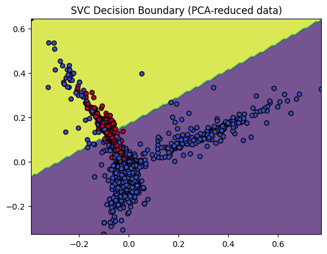

```python
import matplotlib.pyplot as plt
from sklearn.decomposition import PCA

# Apply PCA to reduce dimensionality to 2 components for visualization
pca = PCA(n_components=2)
X_train_pca = pca.fit_transform(X_train) # Removed .toarray()

# Fit the model to the reduced data
best_model.fit(X_train_pca, y_train)

# Plot decision boundary
xx, yy = np.meshgrid(np.linspace(X_train_pca[:, 0].min(), X_train_pca[:, 0].max(), 100),
                     np.linspace(X_train_pca[:, 1].min(), X_train_pca[:, 1].max(), 100))
Z = best_model.predict(np.c_[xx.ravel(), yy.ravel()])
Z = Z.reshape(xx.shape)

plt.contourf(xx, yy, Z, alpha=0.75)
plt.scatter(X_train_pca[:, 0], X_train_pca[:, 1], c=y_train, s=30, edgecolor='k', cmap='coolwarm')
plt.title("SVC Decision Boundary (PCA-reduced data)")
plt.show()
```